# Técnica de análisis no supervisado con K-Means

Obed Rios Ruíz - Daniel Román Ramírez

# Contextualización

El aprendizaje supervisado son un conjunto de técnicas que permiten inferir modelos para extraer conocimiento de conjuntos de datos donde a priori se desconoce.

Las técnicas de aprendizaje no supervisado se pueden aplicar sin necesidad de tener los datos etiquetados para el entrenamiento.

Como solo conocemos datos de entrada, pero no existen datos de salida que correspondan con las entradas, sólo se puede describir la estructura de los datos y con ello intentar encontrar algún tipo de organización que simplifique el análisis, por lo que tiene carácter exploratorio.

En efecto se distingue del Aprendizaje supervisado por el hecho de que no hay un conocimiento a priori. En el aprendizaje no supervisado, un conjunto de datos de objetos de entrada es tratado. Así, el aprendizaje no supervisado típicamente trata los objetos de entrada como un conjunto de variables aleatorias, siendo construido un modelo de densidad para el conjunto de datos.

El aprendizaje no supervisado se puede usar en conjunto con la Inferencia bayesiana para producir probabilidades condicionales (es decir, aprendizaje supervisado) para cualquiera de las variables aleatorias dadas.

los modelos de aprendizaje no supervisado son aquellos en los que se interesa en producir una función que se ajuste a una salida deseada obtenida a priori, sino en aumentar el conocimiento de los datos disponibles (y posibles datos futuros), por ejemplo, dando una agrupación de los ejemplos según su similaridad (clustering), o simplificando las estructura de los mismos manteniendo sus características fundamentales (como en reducción de la dimensionalidad).

# Desarrollo

Se tiene dos bases de datos que relacionan estudiantes con el consumo de alcohol, y se quiere analizar si existe relación alguna entre el consumo de alcohol y los resultados de las notas académicas.La base de datos contiene información social y académica de un grupo de estudiantes de secundaria de edades entre los 15 y 22 años de dos escuelas de portugal.

# Fases de desarrollo

Con el fin de detectar algúna relación del consumo de alcohol con las notas académicas de los estudiantes de estas instituciones educativas se plantea los siguientes pasos para ejecutar los análisis.

- *Analisis y exploración de la calidad de los datos*
- *Detectar si existen valores outliers*
- *Entendimiento de datos por medio de visualizaciones*
- *Entender los datos a través del análisis estadístico univariante y bivariante*
- *Segmentar los datos: K-Means*
- *Entendimiento del funcionamiento del algoritmo de k-means*
- *Conclusiones e interpretación final*

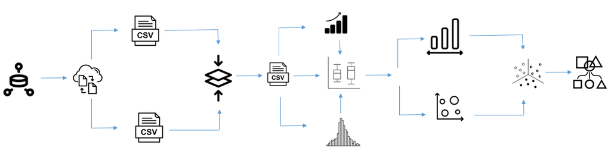

# Preparación de los datos

```r
colorize <- function(x, color) {
  if (knitr::is_latex_output()) {
    sprintf("\\textcolor{%s}{%s}", color, x)
  } else if (knitr::is_html_output()) {
    sprintf("<span style='color: %s;'>%s</span>", color,
      x)
  } else x
}
```

```r
setwd("C:/Users/droma/Universidad EAFIT/Aprendizaje Automático - General/Análisis_No_Supervisado") # Directorio de trabajo

library(readr)
library(ggplot2)
library(RColorBrewer)
library(corrplot)
library(dplyr)
```

## Análisis y exploración de la calidad de los datos

A continuación se importarán las bases de datos para el estudio. se procederá a cruzar la información para consolidar y preparar los datos para el análisis exploratiorio y aplicación de análisis no supervisado.

**Base de datos : student-mat**

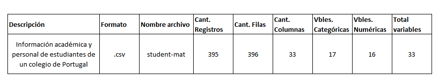

```r
d1<-read_csv("C:/Users/droma/Universidad EAFIT/Aprendizaje Automático - General/Análisis_No_Supervisado/student-mat.csv")
```

#### Dimensión de la base

```r
dim(d1)
```

```
## [1] 395  33
```

#### Estructura de la base

```r
str(d1)
```

```
## Classes 'spec_tbl_df', 'tbl_df', 'tbl' and 'data.frame': 395 obs. of  33 variables:
##  $ school    : chr  "GP" "GP" "GP" "GP" ...
##  $ sex       : chr  "F" "F" "F" "F" ...
##  $ age       : num  18 17 15 15 16 16 16 17 15 15 ...
##  $ address   : chr  "U" "U" "U" "U" ...
##  $ famsize   : chr  "GT3" "GT3" "LE3" "GT3" ...
##  $ Pstatus   : chr  "A" "T" "T" "T" ...
##  $ Medu      : num  4 1 1 4 3 4 2 4 3 3 ...
##  $ Fedu      : num  4 1 1 2 3 3 2 4 2 4 ...
##  $ Mjob      : chr  "at_home" "at_home" "at_home" "health" ...
##  $ Fjob      : chr  "teacher" "other" "other" "services" ...
##  $ reason    : chr  "course" "course" "other" "home" ...
##  $ guardian  : chr  "mother" "father" "mother" "mother" ...
##  $ traveltime: num  2 1 1 1 1 1 1 2 1 1 ...
##  $ studytime : num  2 2 2 3 2 2 2 2 2 2 ...
##  $ failures  : num  0 0 3 0 0 0 0 0 0 0 ...
##  $ schoolsup : chr  "yes" "no" "yes" "no" ...
##  $ famsup    : chr  "no" "yes" "no" "yes" ...
##  $ paid      : chr  "no" "no" "yes" "yes" ...
##  $ activities: chr  "no" "no" "no" "yes" ...
##  $ nursery   : chr  "yes" "no" "yes" "yes" ...
##  $ higher    : chr  "yes" "yes" "yes" "yes" ...
##  $ internet  : chr  "no" "yes" "yes" "yes" ...
##  $ romantic  : chr  "no" "no" "no" "yes" ...
##  $ famrel    : num  4 5 4 3 4 5 4 4 4 5 ...
##  $ freetime  : num  3 3 3 2 3 4 4 1 2 5 ...
##  $ goout     : num  4 3 2 2 2 2 4 4 2 1 ...
##  $ Dalc      : num  1 1 2 1 1 1 1 1 1 1 ...
##  $ Walc      : num  1 1 3 1 2 2 1 1 1 1 ...
##  $ health    : num  3 3 3 5 5 5 3 1 1 5 ...
##  $ absences  : num  6 4 10 2 4 10 0 6 0 0 ...
##  $ G1        : num  5 5 7 15 6 15 12 6 16 14 ...
##  $ G2        : num  6 5 8 14 10 15 12 5 18 15 ...
##  $ G3        : num  6 6 10 15 10 15 11 6 19 15 ...
##  - attr(*, "spec")=
##   .. cols(
##   ..   school = col_character(),
##   ..   sex = col_character(),
##   ..   age = col_double(),
##   ..   address = col_character(),
```

[output cut: 15 more lines]

```
##   ..   nursery = col_character(),
##   ..   higher = col_character(),
##   ..   internet = col_character(),
##   ..   romantic = col_character(),
##   ..   famrel = col_double(),
##   ..   freetime = col_double(),
##   ..   goout = col_double(),
##   ..   Dalc = col_double(),
##   ..   Walc = col_double(),
##   ..   health = col_double(),
##   ..   absences = col_double(),
##   ..   G1 = col_double(),
##   ..   G2 = col_double(),
##   ..   G3 = col_double()
##   .. )
```

### Resumen de la base

```r
summary(d1)
```

```
##     school              sex                 age         address
##  Length:395         Length:395         Min.   :15.0   Length:395
##  Class :character   Class :character   1st Qu.:16.0   Class :character
##  Mode  :character   Mode  :character   Median :17.0   Mode  :character
##                                        Mean   :16.7
##                                        3rd Qu.:18.0
##                                        Max.   :22.0
##    famsize            Pstatus               Medu            Fedu
##  Length:395         Length:395         Min.   :0.000   Min.   :0.000
##  Class :character   Class :character   1st Qu.:2.000   1st Qu.:2.000
##  Mode  :character   Mode  :character   Median :3.000   Median :2.000
##                                        Mean   :2.749   Mean   :2.522
##                                        3rd Qu.:4.000   3rd Qu.:3.000
##                                        Max.   :4.000   Max.   :4.000
##      Mjob               Fjob              reason            guardian
##  Length:395         Length:395         Length:395         Length:395
##  Class :character   Class :character   Class :character   Class :character
##  Mode  :character   Mode  :character   Mode  :character   Mode  :character
##
##
##
##    traveltime      studytime        failures       schoolsup
##  Min.   :1.000   Min.   :1.000   Min.   :0.0000   Length:395
##  1st Qu.:1.000   1st Qu.:1.000   1st Qu.:0.0000   Class :character
##  Median :1.000   Median :2.000   Median :0.0000   Mode  :character
##  Mean   :1.448   Mean   :2.035   Mean   :0.3342
##  3rd Qu.:2.000   3rd Qu.:2.000   3rd Qu.:0.0000
##  Max.   :4.000   Max.   :4.000   Max.   :3.0000
##     famsup              paid            activities          nursery
##  Length:395         Length:395         Length:395         Length:395
##  Class :character   Class :character   Class :character   Class :character
##  Mode  :character   Mode  :character   Mode  :character   Mode  :character
##
##
##
##     higher            internet           romantic             famrel
##  Length:395         Length:395         Length:395         Min.   :1.000
##  Class :character   Class :character   Class :character   1st Qu.:4.000
##  Mode  :character   Mode  :character   Mode  :character   Median :4.000
##                                                           Mean   :3.944
```

[output cut: 8 more lines]

```
##  Max.   :5.000   Max.   :5.000   Max.   :5.000   Max.   :5.000
##      health         absences            G1              G2
##  Min.   :1.000   Min.   : 0.000   Min.   : 3.00   Min.   : 0.00
##  1st Qu.:3.000   1st Qu.: 0.000   1st Qu.: 8.00   1st Qu.: 9.00
##  Median :4.000   Median : 4.000   Median :11.00   Median :11.00
##  Mean   :3.554   Mean   : 5.709   Mean   :10.91   Mean   :10.71
##  3rd Qu.:5.000   3rd Qu.: 8.000   3rd Qu.:13.00   3rd Qu.:13.00
##  Max.   :5.000   Max.   :75.000   Max.   :19.00   Max.   :19.00
##        G3
##  Min.   : 0.00
##  1st Qu.: 8.00
##  Median :11.00
##  Mean   :10.42
##  3rd Qu.:14.00
##  Max.   :20.00
```

#### Base de datos : student-por

En este otra base de datos contiene otro grupo de estudiantes de otro colegio de Portugal, esta contiene 649 registros, distribuidas en 33 variables, en las cuales son 17 categóricas y 16 numéricas.

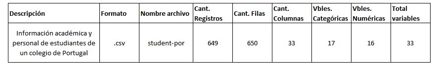

```r
d2<-read_csv("C:/Users/droma/Universidad EAFIT/Aprendizaje Automático - General/Análisis_No_Supervisado/student-por.csv")
```

#### Dimensión de la base

```r
dim(d2)
```

```
## [1] 649  33
```

#### Estructura de la base

```r
str(d2)
```

```
## Classes 'spec_tbl_df', 'tbl_df', 'tbl' and 'data.frame': 649 obs. of  33 variables:
##  $ school    : chr  "GP" "GP" "GP" "GP" ...
##  $ sex       : chr  "F" "F" "F" "F" ...
##  $ age       : num  18 17 15 15 16 16 16 17 15 15 ...
##  $ address   : chr  "U" "U" "U" "U" ...
##  $ famsize   : chr  "GT3" "GT3" "LE3" "GT3" ...
##  $ Pstatus   : chr  "A" "T" "T" "T" ...
##  $ Medu      : num  4 1 1 4 3 4 2 4 3 3 ...
##  $ Fedu      : num  4 1 1 2 3 3 2 4 2 4 ...
##  $ Mjob      : chr  "at_home" "at_home" "at_home" "health" ...
##  $ Fjob      : chr  "teacher" "other" "other" "services" ...
##  $ reason    : chr  "course" "course" "other" "home" ...
##  $ guardian  : chr  "mother" "father" "mother" "mother" ...
##  $ traveltime: num  2 1 1 1 1 1 1 2 1 1 ...
##  $ studytime : num  2 2 2 3 2 2 2 2 2 2 ...
##  $ failures  : num  0 0 0 0 0 0 0 0 0 0 ...
##  $ schoolsup : chr  "yes" "no" "yes" "no" ...
##  $ famsup    : chr  "no" "yes" "no" "yes" ...
##  $ paid      : chr  "no" "no" "no" "no" ...
##  $ activities: chr  "no" "no" "no" "yes" ...
##  $ nursery   : chr  "yes" "no" "yes" "yes" ...
##  $ higher    : chr  "yes" "yes" "yes" "yes" ...
##  $ internet  : chr  "no" "yes" "yes" "yes" ...
##  $ romantic  : chr  "no" "no" "no" "yes" ...
##  $ famrel    : num  4 5 4 3 4 5 4 4 4 5 ...
##  $ freetime  : num  3 3 3 2 3 4 4 1 2 5 ...
##  $ goout     : num  4 3 2 2 2 2 4 4 2 1 ...
##  $ Dalc      : num  1 1 2 1 1 1 1 1 1 1 ...
##  $ Walc      : num  1 1 3 1 2 2 1 1 1 1 ...
##  $ health    : num  3 3 3 5 5 5 3 1 1 5 ...
##  $ absences  : num  4 2 6 0 0 6 0 2 0 0 ...
##  $ G1        : num  0 9 12 14 11 12 13 10 15 12 ...
##  $ G2        : num  11 11 13 14 13 12 12 13 16 12 ...
##  $ G3        : num  11 11 12 14 13 13 13 13 17 13 ...
##  - attr(*, "spec")=
##   .. cols(
##   ..   school = col_character(),
##   ..   sex = col_character(),
##   ..   age = col_double(),
##   ..   address = col_character(),
```

[output cut: 15 more lines]

```
##   ..   nursery = col_character(),
##   ..   higher = col_character(),
##   ..   internet = col_character(),
##   ..   romantic = col_character(),
##   ..   famrel = col_double(),
##   ..   freetime = col_double(),
##   ..   goout = col_double(),
##   ..   Dalc = col_double(),
##   ..   Walc = col_double(),
##   ..   health = col_double(),
##   ..   absences = col_double(),
##   ..   G1 = col_double(),
##   ..   G2 = col_double(),
##   ..   G3 = col_double()
##   .. )
```

#### Resumen de la base

```r
summary(d2)
```

```
##     school              sex                 age          address
##  Length:649         Length:649         Min.   :15.00   Length:649
##  Class :character   Class :character   1st Qu.:16.00   Class :character
##  Mode  :character   Mode  :character   Median :17.00   Mode  :character
##                                        Mean   :16.74
##                                        3rd Qu.:18.00
##                                        Max.   :22.00
##    famsize            Pstatus               Medu            Fedu
##  Length:649         Length:649         Min.   :0.000   Min.   :0.000
##  Class :character   Class :character   1st Qu.:2.000   1st Qu.:1.000
##  Mode  :character   Mode  :character   Median :2.000   Median :2.000
##                                        Mean   :2.515   Mean   :2.307
##                                        3rd Qu.:4.000   3rd Qu.:3.000
##                                        Max.   :4.000   Max.   :4.000
##      Mjob               Fjob              reason            guardian
##  Length:649         Length:649         Length:649         Length:649
##  Class :character   Class :character   Class :character   Class :character
##  Mode  :character   Mode  :character   Mode  :character   Mode  :character
##
##
##
##    traveltime      studytime        failures       schoolsup
##  Min.   :1.000   Min.   :1.000   Min.   :0.0000   Length:649
##  1st Qu.:1.000   1st Qu.:1.000   1st Qu.:0.0000   Class :character
##  Median :1.000   Median :2.000   Median :0.0000   Mode  :character
##  Mean   :1.569   Mean   :1.931   Mean   :0.2219
##  3rd Qu.:2.000   3rd Qu.:2.000   3rd Qu.:0.0000
##  Max.   :4.000   Max.   :4.000   Max.   :3.0000
##     famsup              paid            activities          nursery
##  Length:649         Length:649         Length:649         Length:649
##  Class :character   Class :character   Class :character   Class :character
##  Mode  :character   Mode  :character   Mode  :character   Mode  :character
##
##
##
##     higher            internet           romantic             famrel
##  Length:649         Length:649         Length:649         Min.   :1.000
##  Class :character   Class :character   Class :character   1st Qu.:4.000
##  Mode  :character   Mode  :character   Mode  :character   Median :4.000
##                                                           Mean   :3.931
##                                                           3rd Qu.:5.000
##                                                           Max.   :5.000
##     freetime        goout            Dalc            Walc          health
##  Min.   :1.00   Min.   :1.000   Min.   :1.000   Min.   :1.00   Min.   :1.000
##  1st Qu.:3.00   1st Qu.:2.000   1st Qu.:1.000   1st Qu.:1.00   1st Qu.:2.000
##  Median :3.00   Median :3.000   Median :1.000   Median :2.00   Median :4.000
##  Mean   :3.18   Mean   :3.185   Mean   :1.502   Mean   :2.28   Mean   :3.536
##  3rd Qu.:4.00   3rd Qu.:4.000   3rd Qu.:2.000   3rd Qu.:3.00   3rd Qu.:5.000
##  Max.   :5.00   Max.   :5.000   Max.   :5.000   Max.   :5.00   Max.   :5.000
##     absences            G1             G2              G3
##  Min.   : 0.000   Min.   : 0.0   Min.   : 0.00   Min.   : 0.00
##  1st Qu.: 0.000   1st Qu.:10.0   1st Qu.:10.00   1st Qu.:10.00
##  Median : 2.000   Median :11.0   Median :11.00   Median :12.00
##  Mean   : 3.659   Mean   :11.4   Mean   :11.57   Mean   :11.91
##  3rd Qu.: 6.000   3rd Qu.:13.0   3rd Qu.:13.00   3rd Qu.:14.00
##  Max.   :32.000   Max.   :19.0   Max.   :19.00   Max.   :19.00
```

### Unión de las bases de datos

En esta sección se realiza el cruce de información de las dos bases para la consolidación de todos los registros en un solo dataset para el análisis posterior

```r
# añadir marca de fichero
d1$file<-"math"
d2$file<-"portuguese"

# añadir marca de asignatura
d1$subject<-"math"
d2$subject<-"portuguese"

# combinar los dos ficheros
data<-rbind(d1,d2)
```

#### Resumen del nuevo data set

```r
# resumen data
dim(data)
```

```
## [1] 1044   35
```

```r
str(data)
```

```
## Classes 'spec_tbl_df', 'tbl_df', 'tbl' and 'data.frame': 1044 obs. of  35 variables:
##  $ school    : chr  "GP" "GP" "GP" "GP" ...
##  $ sex       : chr  "F" "F" "F" "F" ...
##  $ age       : num  18 17 15 15 16 16 16 17 15 15 ...
##  $ address   : chr  "U" "U" "U" "U" ...
##  $ famsize   : chr  "GT3" "GT3" "LE3" "GT3" ...
##  $ Pstatus   : chr  "A" "T" "T" "T" ...
##  $ Medu      : num  4 1 1 4 3 4 2 4 3 3 ...
##  $ Fedu      : num  4 1 1 2 3 3 2 4 2 4 ...
##  $ Mjob      : chr  "at_home" "at_home" "at_home" "health" ...
##  $ Fjob      : chr  "teacher" "other" "other" "services" ...
##  $ reason    : chr  "course" "course" "other" "home" ...
##  $ guardian  : chr  "mother" "father" "mother" "mother" ...
##  $ traveltime: num  2 1 1 1 1 1 1 2 1 1 ...
##  $ studytime : num  2 2 2 3 2 2 2 2 2 2 ...
##  $ failures  : num  0 0 3 0 0 0 0 0 0 0 ...
##  $ schoolsup : chr  "yes" "no" "yes" "no" ...
##  $ famsup    : chr  "no" "yes" "no" "yes" ...
##  $ paid      : chr  "no" "no" "yes" "yes" ...
##  $ activities: chr  "no" "no" "no" "yes" ...
##  $ nursery   : chr  "yes" "no" "yes" "yes" ...
##  $ higher    : chr  "yes" "yes" "yes" "yes" ...
##  $ internet  : chr  "no" "yes" "yes" "yes" ...
##  $ romantic  : chr  "no" "no" "no" "yes" ...
##  $ famrel    : num  4 5 4 3 4 5 4 4 4 5 ...
##  $ freetime  : num  3 3 3 2 3 4 4 1 2 5 ...
##  $ goout     : num  4 3 2 2 2 2 4 4 2 1 ...
##  $ Dalc      : num  1 1 2 1 1 1 1 1 1 1 ...
##  $ Walc      : num  1 1 3 1 2 2 1 1 1 1 ...
##  $ health    : num  3 3 3 5 5 5 3 1 1 5 ...
##  $ absences  : num  6 4 10 2 4 10 0 6 0 0 ...
##  $ G1        : num  5 5 7 15 6 15 12 6 16 14 ...
##  $ G2        : num  6 5 8 14 10 15 12 5 18 15 ...
##  $ G3        : num  6 6 10 15 10 15 11 6 19 15 ...
##  $ file      : chr  "math" "math" "math" "math" ...
##  $ subject   : chr  "math" "math" "math" "math" ...
##  - attr(*, "spec")=
##   .. cols(
##   ..   school = col_character(),
##   ..   sex = col_character(),
```

[output cut: 17 more lines]

```
##   ..   nursery = col_character(),
##   ..   higher = col_character(),
##   ..   internet = col_character(),
##   ..   romantic = col_character(),
##   ..   famrel = col_double(),
##   ..   freetime = col_double(),
##   ..   goout = col_double(),
##   ..   Dalc = col_double(),
##   ..   Walc = col_double(),
##   ..   health = col_double(),
##   ..   absences = col_double(),
##   ..   G1 = col_double(),
##   ..   G2 = col_double(),
##   ..   G3 = col_double()
##   .. )
```

```r
summary(data)
```

```
##     school              sex                 age          address
##  Length:1044        Length:1044        Min.   :15.00   Length:1044
##  Class :character   Class :character   1st Qu.:16.00   Class :character
##  Mode  :character   Mode  :character   Median :17.00   Mode  :character
##                                        Mean   :16.73
##                                        3rd Qu.:18.00
##                                        Max.   :22.00
##    famsize            Pstatus               Medu            Fedu
##  Length:1044        Length:1044        Min.   :0.000   Min.   :0.000
##  Class :character   Class :character   1st Qu.:2.000   1st Qu.:1.000
##  Mode  :character   Mode  :character   Median :3.000   Median :2.000
##                                        Mean   :2.603   Mean   :2.388
##                                        3rd Qu.:4.000   3rd Qu.:3.000
##                                        Max.   :4.000   Max.   :4.000
##      Mjob               Fjob              reason            guardian
##  Length:1044        Length:1044        Length:1044        Length:1044
##  Class :character   Class :character   Class :character   Class :character
##  Mode  :character   Mode  :character   Mode  :character   Mode  :character
##
##
##
##    traveltime      studytime       failures       schoolsup
##  Min.   :1.000   Min.   :1.00   Min.   :0.0000   Length:1044
##  1st Qu.:1.000   1st Qu.:1.00   1st Qu.:0.0000   Class :character
##  Median :1.000   Median :2.00   Median :0.0000   Mode  :character
##  Mean   :1.523   Mean   :1.97   Mean   :0.2644
##  3rd Qu.:2.000   3rd Qu.:2.00   3rd Qu.:0.0000
##  Max.   :4.000   Max.   :4.00   Max.   :3.0000
##     famsup              paid            activities          nursery
##  Length:1044        Length:1044        Length:1044        Length:1044
##  Class :character   Class :character   Class :character   Class :character
##  Mode  :character   Mode  :character   Mode  :character   Mode  :character
##
##
##
##     higher            internet           romantic             famrel
##  Length:1044        Length:1044        Length:1044        Min.   :1.000
##  Class :character   Class :character   Class :character   1st Qu.:4.000
##  Mode  :character   Mode  :character   Mode  :character   Median :4.000
##                                                           Mean   :3.936
```

[output cut: 8 more lines]

```
##  Max.   :5.000   Max.   :5.000   Max.   :5.000   Max.   :5.000
##      health         absences            G1              G2
##  Min.   :1.000   Min.   : 0.000   Min.   : 0.00   Min.   : 0.00
##  1st Qu.:3.000   1st Qu.: 0.000   1st Qu.: 9.00   1st Qu.: 9.00
##  Median :4.000   Median : 2.000   Median :11.00   Median :11.00
##  Mean   :3.543   Mean   : 4.435   Mean   :11.21   Mean   :11.25
##  3rd Qu.:5.000   3rd Qu.: 6.000   3rd Qu.:13.00   3rd Qu.:13.00
##  Max.   :5.000   Max.   :75.000   Max.   :19.00   Max.   :19.00
##        G3            file             subject
##  Min.   : 0.00   Length:1044        Length:1044
##  1st Qu.:10.00   Class :character   Class :character
##  Median :11.00   Mode  :character   Mode  :character
##  Mean   :11.34
##  3rd Qu.:14.00
##  Max.   :20.00
```

## Verificación de datos duplicados

Luedo de haber consolidado toda la información se verificará la existencia de datos duplicados

```r
nrow(data)
```

```
## [1] 1044
```

```r
nrow(unique(data))
```

```
## [1] 1044
```

Finalmente se concluye que no hay datos repetidos

### Normalizar nombres de las variables

Es importante que las variables del nuevo dataset estén normalizadas con el fin de obtener la información adecuada en la matriz de datos

```r
colnames(data) <- tolower(colnames(data))
```

### Creación de un identificador único por estudiante

Se creará una variable de identificador único para cada estudiante, esto se hará concatenando ciertas variables las cuales garanterizan la existencia única y exclusiva del estudiante.

```r
data$student_key<-paste(data$school, data$sex, data$age, data$address, data$famsize, data$pstatus, data$medu, data$fedu, data$mjob, data$fjob, data$reason, data$nursery, data$internet, sep="-")
```

### Creación de la variable binaria

En esta sección se creará una variable binaria que indicará si el estudiante aprobó o nó la materia, es decir, 1 es mayor que 10, o 0 si la nota es inferior a 10

```r
data$bing3 <- ifelse(data$g3>=10, 1, 0)
```

Se procede a crear otra variable que indique que si aprueba una asignatura u otra.

```r
data$result <-paste(ifelse(data$g3>=10, "aprueba", "no aprueba"), data$subject, sep=" ")
```

Posteriormente se crea una variable que mida el consumo de alcohol global por medio de la media ponderada por el número de días.

```r
data$alcohol <- round((data$dalc*5 + data$walc*2)/7,2)
```

Se debe identificar los estudiantes repetidos en dos clases, esto con el fin de evitar desbalance de clases

```r
duplicated_rows <- duplicated(data$student_key)
data_duplicated <- data[duplicated_rows,]
nrow(data_duplicated)
```

```
## [1] 382
```

Se evidencia 382 estudiantes que están en ambos ficheros.

Debido a lo anterior se debe crear una función para informar que los estudiantes existen en las dos asignaturas.

```r
add_duplicates_subject <- function(duplicated){

  #data$school, data$sex, data$age, data$address, data$famsize, data$pstatus, data$medu, data$fedu, data$mjob, data$fjob, data$reason, data$nursery, data$internet

        rows <- data$school == duplicated$school &
        data$sex == duplicated$sex &
        data$age == duplicated$age &
        data$address == duplicated$address &
        data$famsize == duplicated$famsize &
        data$pstatus == duplicated$pstatus &
        data$medu == duplicated$medu &
        data$fedu == duplicated$fedu &
        data$mjob == duplicated$mjob &
        data$fjob == duplicated$fjob &
        data$reason == duplicated$reason &
        data$nursery == duplicated$nursery &
        data$internet == duplicated$internet
        # actualizar asignatura
        data[rows,"subject"] <<- "math&portuguese"
}
```

Se aplica la función a los alumnos que se identificaron como repetidos.

```r
for(i in 1:nrow(data_duplicated)){
    add_duplicates_subject(data_duplicated[i,])
}
```

Se guarda la información de los datos

```r
raw_data <- data
```

### Codificación de las variables categóricas

Antes de iniciar un análisis descriptivo se codificarán las variables categóricas para tener un mejor entendimiento del comportamiento de los datos.

```r
data$school <- factor(data$school, labels=c("Gabriel Pereira", "Mousinho da Silveira"))

data$sex <- factor(data$sex, labels=c("female", "male"))

data$address <- factor(data$address, labels=c("rural", "urban"))

data$famsize <- factor(data$famsize, labels=c("greater than 3","less or equal to 3"))

data$pstatus <- factor(data$pstatus, labels=c("living apart","living together"))

data$medu <- factor(data$medu, labels=c("none","primary", "5th-9th grade", "secondary", "higher") )

data$fedu <- factor(data$fedu, labels=c("none","primary", "5th-9th grade", "secondary", "higher") )

data$traveltime <- factor(data$traveltime, labels=c("<15 min.","15 to 30 min.", "30 min to 1 hour", ">1 hour"))

data$studytime <- factor(data$studytime, labels=c("<2 hours","2 to 5 hours", "5 to 10 hours", ">10 hours"))

data$famrel <- factor(data$famrel, labels=c("very bad","bad", "fair", "good", "excellent"))

data$freetime <- factor(data$freetime, labels=c("very low", "low", "medium", "high", "very high"))

data$goout <- factor(data$goout, labels=c("very low", "low", "medium", "high", "very high"))

data$dalc <- factor(data$dalc, labels=c("very low", "low", "medium", "high", "very high"))

data$walc <- factor(data$walc, labels=c("very low", "low", "medium", "high", "very high"))

data$health <- factor(data$health, labels=c("very bad","bad", "fair", "good", "very good"))

data$file <- as.factor(data$file)

data$subject <- as.factor(data$subject)

data$bing3 <- factor(data$bing3, labels=c("fail","pass"))

data$result <- as.factor(data$result)

str(data)
```

```
## Classes 'spec_tbl_df', 'tbl_df', 'tbl' and 'data.frame': 1044 obs. of  39 variables:
##  $ school     : Factor w/ 2 levels "Gabriel Pereira",..: 1 1 1 1 1 1 1 1 1 1 ...
##  $ sex        : Factor w/ 2 levels "female","male": 1 1 1 1 1 2 2 1 2 2 ...
##  $ age        : num  18 17 15 15 16 16 16 17 15 15 ...
##  $ address    : Factor w/ 2 levels "rural","urban": 2 2 2 2 2 2 2 2 2 2 ...
##  $ famsize    : Factor w/ 2 levels "greater than 3",..: 1 1 2 1 1 2 2 1 2 1 ...
##  $ pstatus    : Factor w/ 2 levels "living apart",..: 1 2 2 2 2 2 2 1 1 2 ...
##  $ medu       : Factor w/ 5 levels "none","primary",..: 5 2 2 5 4 5 3 5 4 4 ...
##  $ fedu       : Factor w/ 5 levels "none","primary",..: 5 2 2 3 4 4 3 5 3 5 ...
##  $ mjob       : chr  "at_home" "at_home" "at_home" "health" ...
##  $ fjob       : chr  "teacher" "other" "other" "services" ...
##  $ reason     : chr  "course" "course" "other" "home" ...
##  $ guardian   : chr  "mother" "father" "mother" "mother" ...
##  $ traveltime : Factor w/ 4 levels "<15 min.","15 to 30 min.",..: 2 1 1 1 1 1 1 2 1 1 ...
##  $ studytime  : Factor w/ 4 levels "<2 hours","2 to 5 hours",..: 2 2 2 3 2 2 2 2 2 2 ...
##  $ failures   : num  0 0 3 0 0 0 0 0 0 0 ...
##  $ schoolsup  : chr  "yes" "no" "yes" "no" ...
##  $ famsup     : chr  "no" "yes" "no" "yes" ...
##  $ paid       : chr  "no" "no" "yes" "yes" ...
##  $ activities : chr  "no" "no" "no" "yes" ...
##  $ nursery    : chr  "yes" "no" "yes" "yes" ...
##  $ higher     : chr  "yes" "yes" "yes" "yes" ...
##  $ internet   : chr  "no" "yes" "yes" "yes" ...
##  $ romantic   : chr  "no" "no" "no" "yes" ...
##  $ famrel     : Factor w/ 5 levels "very bad","bad",..: 4 5 4 3 4 5 4 4 4 5 ...
##  $ freetime   : Factor w/ 5 levels "very low","low",..: 3 3 3 2 3 4 4 1 2 5 ...
##  $ goout      : Factor w/ 5 levels "very low","low",..: 4 3 2 2 2 2 4 4 2 1 ...
##  $ dalc       : Factor w/ 5 levels "very low","low",..: 1 1 2 1 1 1 1 1 1 1 ...
##  $ walc       : Factor w/ 5 levels "very low","low",..: 1 1 3 1 2 2 1 1 1 1 ...
##  $ health     : Factor w/ 5 levels "very bad","bad",..: 3 3 3 5 5 5 3 1 1 5 ...
##  $ absences   : num  6 4 10 2 4 10 0 6 0 0 ...
##  $ g1         : num  5 5 7 15 6 15 12 6 16 14 ...
##  $ g2         : num  6 5 8 14 10 15 12 5 18 15 ...
##  $ g3         : num  6 6 10 15 10 15 11 6 19 15 ...
##  $ file       : Factor w/ 2 levels "math","portuguese": 1 1 1 1 1 1 1 1 1 1 ...
##  $ subject    : Factor w/ 3 levels "math","math&portuguese",..: 2 2 2 2 2 2 2 2 2 2 ...
##  $ student_key: chr  "GP-F-18-U-GT3-A-4-4-at_home-teacher-course-yes-no" "GP-F-17-U-GT3-T-1-1-at_home-other-course-no-yes" "GP-F-15-U-LE3-T-1-1-at_home-other-other-yes-yes" "GP-F-15-U-GT3-T-4-2-health-services-home-yes-yes" ...
##  $ bing3      : Factor w/ 2 levels "fail","pass": 1 1 2 2 2 2 2 1 2 2 ...
##  $ result     : Factor w/ 4 levels "aprueba math",..: 3 3 1 1 1 1 1 3 1 1 ...
##  $ alcohol    : num  1 1 2.29 1 1.29 1.29 1 1 1 1 ...
```

[output cut: 21 more lines]

```
##   ..   nursery = col_character(),
##   ..   higher = col_character(),
##   ..   internet = col_character(),
##   ..   romantic = col_character(),
##   ..   famrel = col_double(),
##   ..   freetime = col_double(),
##   ..   goout = col_double(),
##   ..   Dalc = col_double(),
##   ..   Walc = col_double(),
##   ..   health = col_double(),
##   ..   absences = col_double(),
##   ..   G1 = col_double(),
##   ..   G2 = col_double(),
##   ..   G3 = col_double()
##   .. )
```

#### Resumen de los datos

```r
summary(data)
```

```
##                   school        sex           age         address
##  Gabriel Pereira     :772   female:591   Min.   :15.00   rural:285
##  Mousinho da Silveira:272   male  :453   1st Qu.:16.00   urban:759
##                                          Median :17.00
##                                          Mean   :16.73
##                                          3rd Qu.:18.00
##                                          Max.   :22.00
##                famsize               pstatus               medu
##  greater than 3    :738   living apart   :121   none         :  9
##  less or equal to 3:306   living together:923   primary      :202
##                                                 5th-9th grade:289
##                                                 secondary    :238
##                                                 higher       :306
##
##             fedu         mjob               fjob              reason
##  none         :  9   Length:1044        Length:1044        Length:1044
##  primary      :256   Class :character   Class :character   Class :character
##  5th-9th grade:324   Mode  :character   Mode  :character   Mode  :character
##  secondary    :231
##  higher       :224
##
##    guardian                    traveltime          studytime      failures
##  Length:1044        <15 min.        :623   <2 hours     :317   Min.   :0.0000
##  Class :character   15 to 30 min.   :320   2 to 5 hours :503   1st Qu.:0.0000
##  Mode  :character   30 min to 1 hour: 77   5 to 10 hours:162   Median :0.0000
##                     >1 hour         : 24   >10 hours    : 62   Mean   :0.2644
##                                                                3rd Qu.:0.0000
##                                                                Max.   :3.0000
##   schoolsup            famsup              paid            activities
##  Length:1044        Length:1044        Length:1044        Length:1044
##  Class :character   Class :character   Class :character   Class :character
##  Mode  :character   Mode  :character   Mode  :character   Mode  :character
##
##
##
##    nursery             higher            internet           romantic
##  Length:1044        Length:1044        Length:1044        Length:1044
##  Class :character   Class :character   Class :character   Class :character
##  Mode  :character   Mode  :character   Mode  :character   Mode  :character
##
```

[output cut: 15 more lines]

```
##                                  Max.   :75.000   Max.   :19.00
##        g2              g3                file                subject
##  Min.   : 0.00   Min.   : 0.00   math      :395   math           : 25
##  1st Qu.: 9.00   1st Qu.:10.00   portuguese:649   math&portuguese:751
##  Median :11.00   Median :11.00                    portuguese     :268
##  Mean   :11.25   Mean   :11.34
##  3rd Qu.:13.00   3rd Qu.:14.00
##  Max.   :19.00   Max.   :20.00
##  student_key         bing3                       result       alcohol
##  Length:1044        fail:230   aprueba math         :265   Min.   :1.000
##  Class :character   pass:814   aprueba portuguese   :549   1st Qu.:1.000
##  Mode  :character              no aprueba math      :130   Median :1.290
##                                no aprueba portuguese:100   Mean   :1.721
##                                                            3rd Qu.:2.178
##                                                            Max.   :5.000
```

```r
variables<-data.frame(names(data), "", sapply(data, class), 0, 0, "")
names(variables)<-c("variable", "descripcion", "tipo", "cuenta_null", "cuenta_na", "color")
```

### Calidad de nombres de los objetos de las variables

Es importante que los nombres queden en calidad para la identificación posterior de las mismas.

```r
variables$descripcion<-as.character(variables$descripcion)

variables$descripcion[1]="Student's school"
variables$descripcion[2]="Student's sex"
variables$descripcion[3]="Student's age"
variables$descripcion[4]="Student's home address type"
variables$descripcion[5]="Family size"
variables$descripcion[6]="Parent's cohabitation status"
variables$descripcion[7]="Mother's education"
variables$descripcion[8]="Father's education"
variables$descripcion[9]="Mother's job"
variables$descripcion[10]="Father's job"
variables$descripcion[11]="Reason to choose this school"
variables$descripcion[12]="Student's guardian"
variables$descripcion[13]="Home to school travel time"
variables$descripcion[14]="Weekly study time"
variables$descripcion[15]="Number of past class failures"
variables$descripcion[16]="Extra educational support"
variables$descripcion[17]="Family educational support"
variables$descripcion[18]="Extra paid classes within the course subject"
variables$descripcion[19]="Extra-curricular activities"
variables$descripcion[20]="Attended nursery school"
variables$descripcion[21]="Wants to take higher education"
variables$descripcion[22]="Internet access at home"
variables$descripcion[23]="With a romantic relationship"
variables$descripcion[24]="Quality of family relationships"
variables$descripcion[25]="Free time after school"
variables$descripcion[26]="Going out with friends"
variables$descripcion[27]="Workday alcohol consumption"
variables$descripcion[28]="Weekend alcohol consumption"
variables$descripcion[29]="Current health status"
variables$descripcion[30]="Number of school absences"
variables$descripcion[31]="First period grade"
variables$descripcion[32]="Second period grade"
variables$descripcion[33]="Final grade"
variables$descripcion[34]="File"
variables$descripcion[35]="Subject"
variables$descripcion[36]="Primary key for student"
variables$descripcion[37]="Binary final grade result"
variables$descripcion[38]="Subject and result"
variables$descripcion[39]="Global alcohol consumption"
```

Para garantizar esta identificación se asignará un color para cada variable

```r
variables$color<-as.character(variables$color)
variables$color[1]="doscolores"
variables$color[2]="doscolores"
variables$color[3]="rainbow"
variables$color[4]="doscolores"
variables$color[5]="doscolores"
variables$color[6]="doscolores"
variables$color[7]="semaforo"
variables$color[8]="semaforo"
variables$color[9]="rainbow"
variables$color[10]="rainbow"
variables$color[11]="rainbow"
variables$color[12]="rainbow"
variables$color[13]="rainbow"
variables$color[14]="semaforo"
variables$color[15]="semaforo_inverso"
variables$color[16]="noyes"
variables$color[17]="noyes"
variables$color[18]="noyes"
variables$color[19]="noyes"
variables$color[20]="noyes"
variables$color[21]="noyes"
variables$color[22]="noyes"
variables$color[23]="noyes"
variables$color[24]="semaforo"
variables$color[25]="semaforo"
variables$color[26]="semaforo"
variables$color[27]="semaforo_inverso"
variables$color[28]="semaforo_inverso"
variables$color[29]="semaforo"
variables$color[30]="heat_inverso"
variables$color[31]="heat"
variables$color[32]="heat"
variables$color[33]="heat"
variables$color[34]="doscolores"
variables$color[35]="rainbow"
variables$color[36]=""
variables$color[37]="noyes"
variables$color[38]="semaforo"
variables$color[39]="heat_inverso"
```

#### Estructura variables numéricas

Es importante observar la estructura de las variables numéricas

```r
variables_numericas<-c(as.character(variables[variables$tipo==c("integer"),1]),
as.character(variables[variables$tipo==c("numeric"),1]))
length(variables_numericas)
```

```
## [1] 7
```

```r
variables_numericas
```

```
## [1] "age"      "failures" "absences" "g1"       "g2"       "g3"       "alcohol"
```

#### Variables discretas

```r
variables_discretas<-as.character(variables[variables$tipo!=c("character"),1])
variables_discretas_names<-as.character(variables[variables$tipo!=c("character"),2])
variables_discretas_color<-as.character(variables[variables$tipo!=c("character"),6])
length(variables_discretas)
```

```
## [1] 26
```

```r
variables_discretas
```

```
##  [1] "school"     "sex"        "age"        "address"    "famsize"
##  [6] "pstatus"    "medu"       "fedu"       "traveltime" "studytime"
## [11] "failures"   "famrel"     "freetime"   "goout"      "dalc"
## [16] "walc"       "health"     "absences"   "g1"         "g2"
## [21] "g3"         "file"       "subject"    "bing3"      "result"
## [26] "alcohol"
```

Eliminación de objetos que no son necesarios

Este paso se realiza para que no genere algún efecto confuso a la hora de invocar datasets u objetos.

```r
rm(d1)
rm(d2)
rm(duplicated_rows)
rm(i)
```

# Calidad de datos

Luegos de haber analizado anterioremente las variables categóricas y numéricas se debe realizar un análisis de detección de *Null’s y datos atípicos* en el dataset esto con el fin de no generar ruido en los resultados finales.

## Detección de Nulls y Na’s

```r
for(i in 1:length(variables$variable)){
  var<-paste(variables$variable[i])
  variables$cuenta_null[i]<-sum(sapply(data[var], function(x) sum(is.null(x))))
  variables$cuenta_na[i]<-sum(sapply(data[var], function(x) sum(is.na(x))))
}

# identificacion de nulos o NA's
nrow(variables[variables$cuenta_null>0,])
```

```
## [1] 0
```

```r
nrow(variables[variables$cuenta_na>0,])
```

```
## [1] 0
```

Aplicando Sapply

```r
sapply (data, function(x) (sum(is.na(x))))
```

```
##      school         sex         age     address     famsize     pstatus
##           0           0           0           0           0           0
##        medu        fedu        mjob        fjob      reason    guardian
##           0           0           0           0           0           0
##  traveltime   studytime    failures   schoolsup      famsup        paid
##           0           0           0           0           0           0
##  activities     nursery      higher    internet    romantic      famrel
##           0           0           0           0           0           0
##    freetime       goout        dalc        walc      health    absences
##           0           0           0           0           0           0
##          g1          g2          g3        file     subject student_key
##           0           0           0           0           0           0
##       bing3      result     alcohol
##           0           0           0
```

```r
sapply (data, function(x) (sum(is.null(x))))
```

```
##      school         sex         age     address     famsize     pstatus
##           0           0           0           0           0           0
##        medu        fedu        mjob        fjob      reason    guardian
##           0           0           0           0           0           0
##  traveltime   studytime    failures   schoolsup      famsup        paid
##           0           0           0           0           0           0
##  activities     nursery      higher    internet    romantic      famrel
##           0           0           0           0           0           0
##    freetime       goout        dalc        walc      health    absences
##           0           0           0           0           0           0
##          g1          g2          g3        file     subject student_key
##           0           0           0           0           0           0
##       bing3      result     alcohol
##           0           0           0
```

# Detectar la existencia de outliers

Se realizarán varias iteraciones para la limpieza de los datos, sin embargo se procederá con mucho detenimiento para no perder información sensible para el modelo.

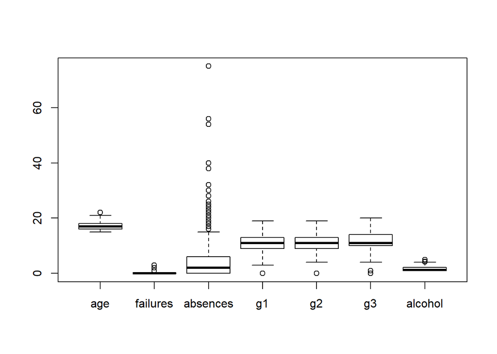

```r
boxplot(data[variables_numericas])
```

Se evidencia valores atípicos en todas las variables numéricas, por tal motivo se detectan y se eliminan estos datos en un nuevo data frame

#### Primera iteración

```r
data_clean1 <- data
dim(data)
```

```
## [1] 1044   39
```

```r
eliminados1 <-0

for(i in 1:length(variables_numericas)){

  variable<-data_clean1[variables_numericas][[i]]
  # usamos boxplot.stats para ver los valores outliers
  outliers<-boxplot.stats(variable)$out
  index <- which( variable %in% outliers)
  eliminados1<-eliminados1+length(index)
  # eliminamos los registros que contienen outliers
  if(length(index)>0) {
    data_clean1<-data_clean1[-index,]
  }

}

eliminados1
```

```
## [1] 283
```

```r
dim(data_clean1)
```

```
## [1] 761  39
```

### Evidencia de la limpieza de los outliers

Efectivamente se presenta una reducción de datos outliers

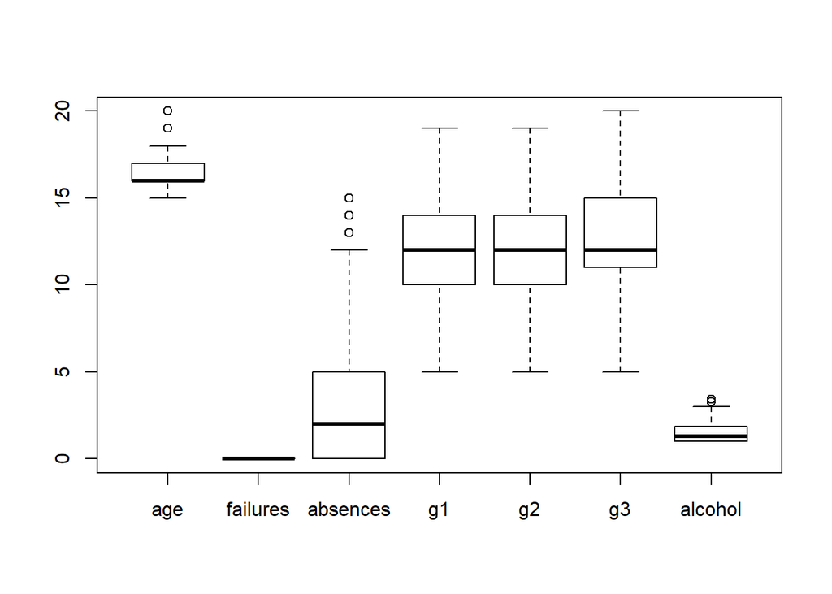

```r
boxplot(data_clean1[variables_numericas])
```

Como aún se evidencia algunos valores atípicos, se procede a realizar la segunda iteración

#### Segunda iteración

```r
data_clean2 <- data_clean1

eliminados2 <-0

for(i in 1:length(variables_numericas)){

  variable<-data_clean2[variables_numericas][[i]]
  # usamos boxplot.stats para ver los valores outliers
  outliers<-boxplot.stats(variable)$out
  index <- which( variable %in% outliers)
  eliminados2<-eliminados2+length(index)
  # eliminamos los registros que contienen outliers
  if(length(index)>0) {
    data_clean2<-data_clean2[-index,]
  }
}

eliminados2
```

```
## [1] 48
```

```r
dim(data_clean2)
```

```
## [1] 713  39
```

Se procede a realizar la verificación de la limpieza

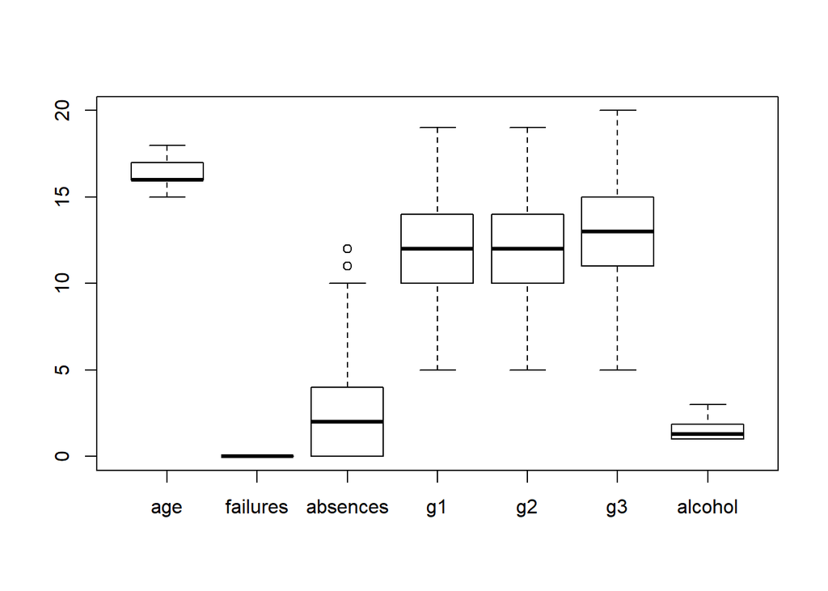

```r
boxplot(data_clean2[variables_numericas])
```

Aún quedan outliers, se realiza la tercera iteración

#### Tercera iteración

```r
data_clean3 <- data_clean2

eliminados3 <-0

for(i in 1:length(variables_numericas)){

  variable<-data_clean3[variables_numericas][[i]]
  # usamos boxplot.stats para ver los valores outliers
  outliers<-boxplot.stats(variable)$out
  index <- which( variable %in% outliers)
  eliminados3<-eliminados3+length(index)
  # eliminamos los registros que contienen outliers
  if(length(index)>0) {
    data_clean3<-data_clean3[-index,]
  }
}

eliminados3
```

```
## [1] 18
```

```r
dim(data_clean3)
```

```
## [1] 695  39
```

Se verifica la existencia de outliers

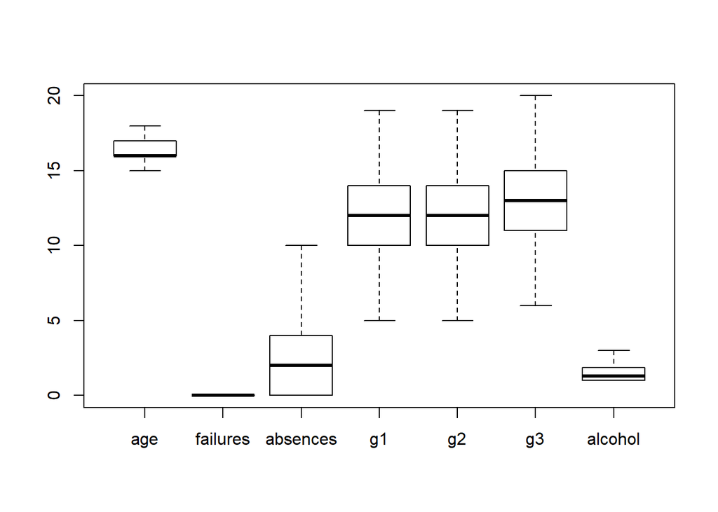

```r
boxplot(data_clean3[variables_numericas])
```

```r
eliminados1+eliminados2+eliminados3
```

```
## [1] 349
```

#### Cuarta iteración

```r
data_clean4 <- data_clean3

eliminados4 <-0

for(i in 1:length(variables_numericas)){

  variable<-data_clean3[variables_numericas][[i]]
  # usamos boxplot.stats para ver los valores outliers
  outliers<-boxplot.stats(variable)$out
  index <- which( variable %in% outliers)
  eliminados4<-eliminados4+length(index)
  # eliminamos los registros que contienen outliers
  if(length(index)>0) {
    data_clean4<-data_clean4[-index,]
  }
}

eliminados4
```

```
## [1] 0
```

```r
dim(data_clean4)
```

```
## [1] 695  39
```

Verificación

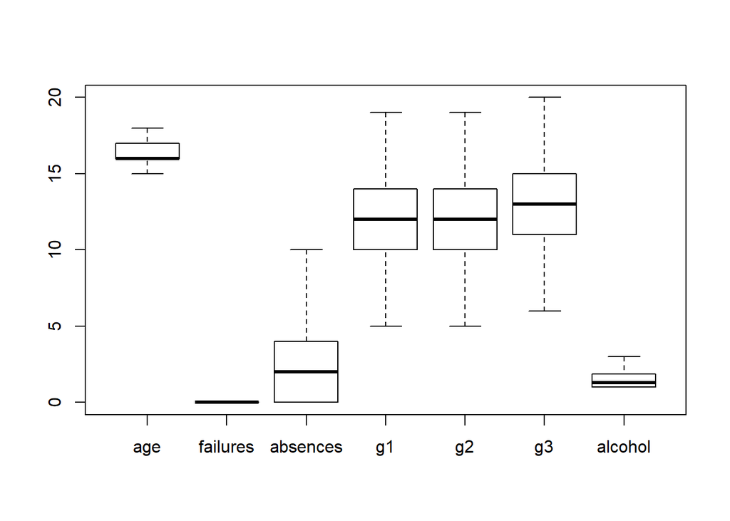

```r
boxplot(data_clean4[variables_numericas])
```

```r
data_clean <- data

summary(data$absences)
```

```
##    Min. 1st Qu.  Median    Mean 3rd Qu.    Max.
##   0.000   0.000   2.000   4.435   6.000  75.000
```

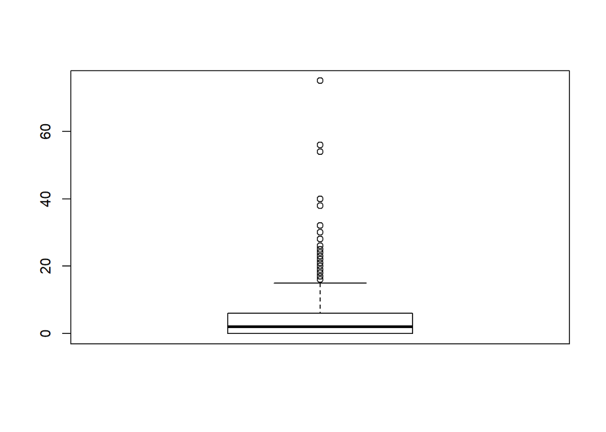

```r
boxplot(data$absences)
```

Se usa boxplot.stats para ver los outliers

```r
  variable<-data_clean$absences

  outliers<-boxplot.stats(variable)$out
  outliers
```

```
##  [1] 16 16 25 54 18 26 20 18 16 16 56 24 18 28 22 16 18 20 16 21 75 22 30 19 20
## [26] 38 18 20 22 40 23 16 17 16 16 24 22 16 32 16 16 30 21 16 18 16 26 16 16 22
## [51] 18 18 16 21
```

```r
table(outliers)
```

```
## outliers
## 16 17 18 19 20 21 22 23 24 25 26 28 30 32 38 40 54 56 75
## 17  1  8  1  4  3  5  1  2  1  2  1  2  1  1  1  1  1  1
```

#### Identificación

```r
index <- which( variable %in% outliers)
  length(index)
```

```
## [1] 54
```

#### Se eliminan los registros outliers

```r
data_clean<-data_clean[-index,]

dim(data[data$absences>15,])
```

```
## [1] 54 39
```

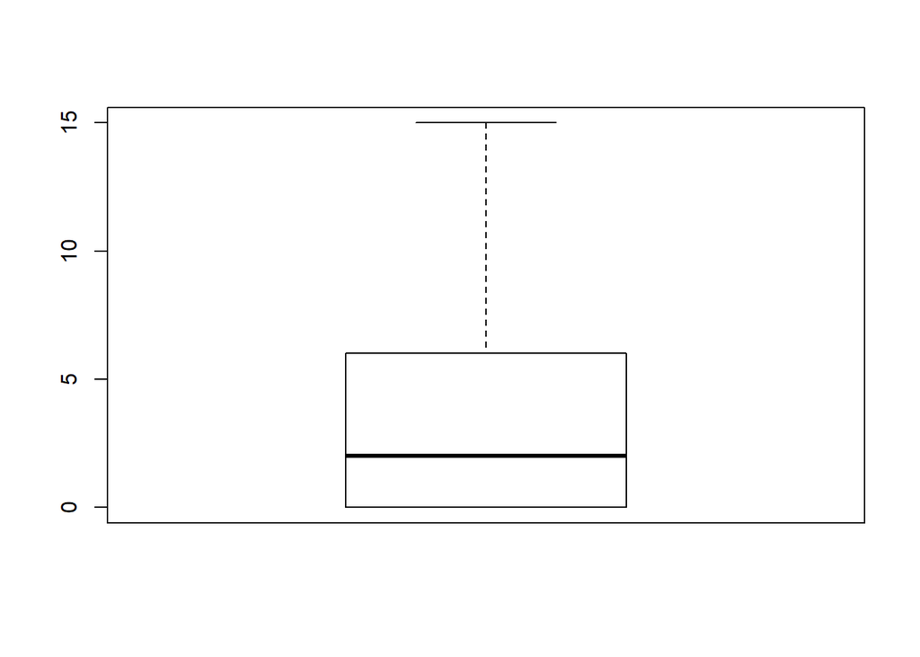

```r
boxplot(data_clean$absences)
```

#### Se evidencia que ya no hay existencia de outliers en esta variable.

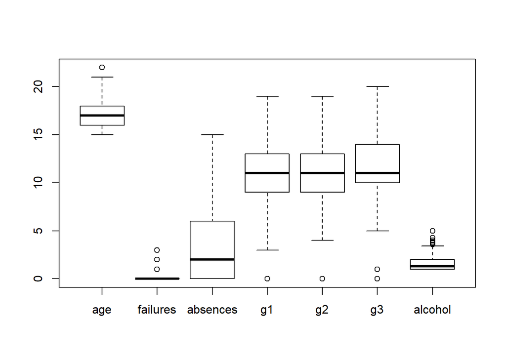

```r
boxplot(data_clean[variables_numericas])
```

#### Se realiza la limpieza de objetos creados que no se usarán mas adelante.

```r
rm(data_clean1)
rm(data_clean2)
rm(data_clean3)
rm(data_clean4)
rm(eliminados1)
rm(eliminados2)
rm(eliminados3)
rm(eliminados4)
rm(i)
rm(index)
rm(outliers)
rm(variable)
rm(var)
```

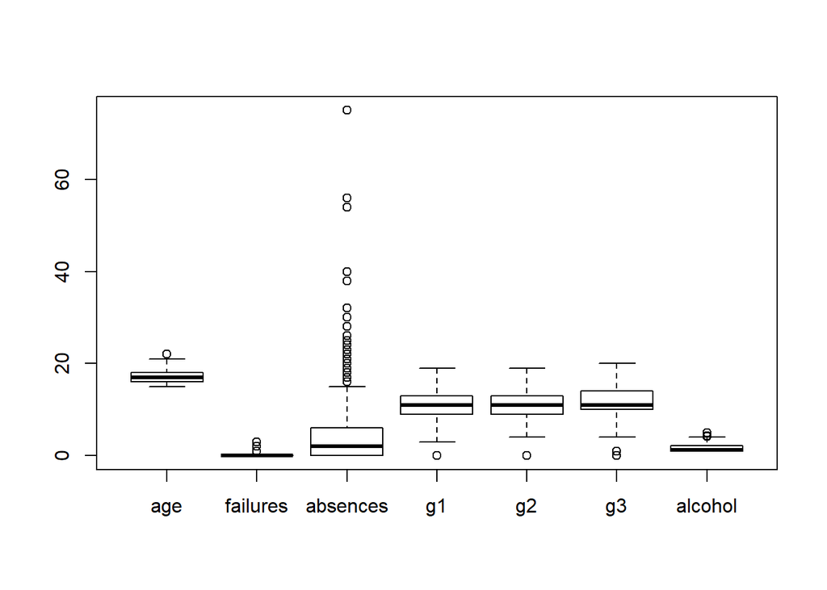

```r
boxplot(data[variables_numericas])
```

#### Comparación para detección de outliers

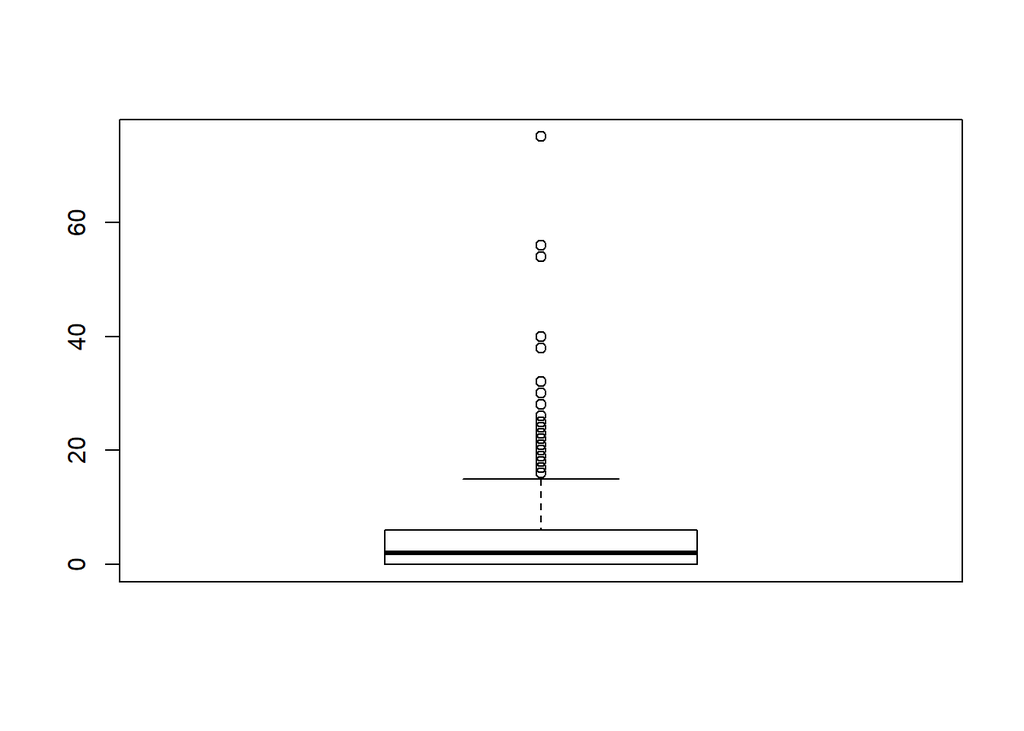

```r
boxplot(data$absences)
```

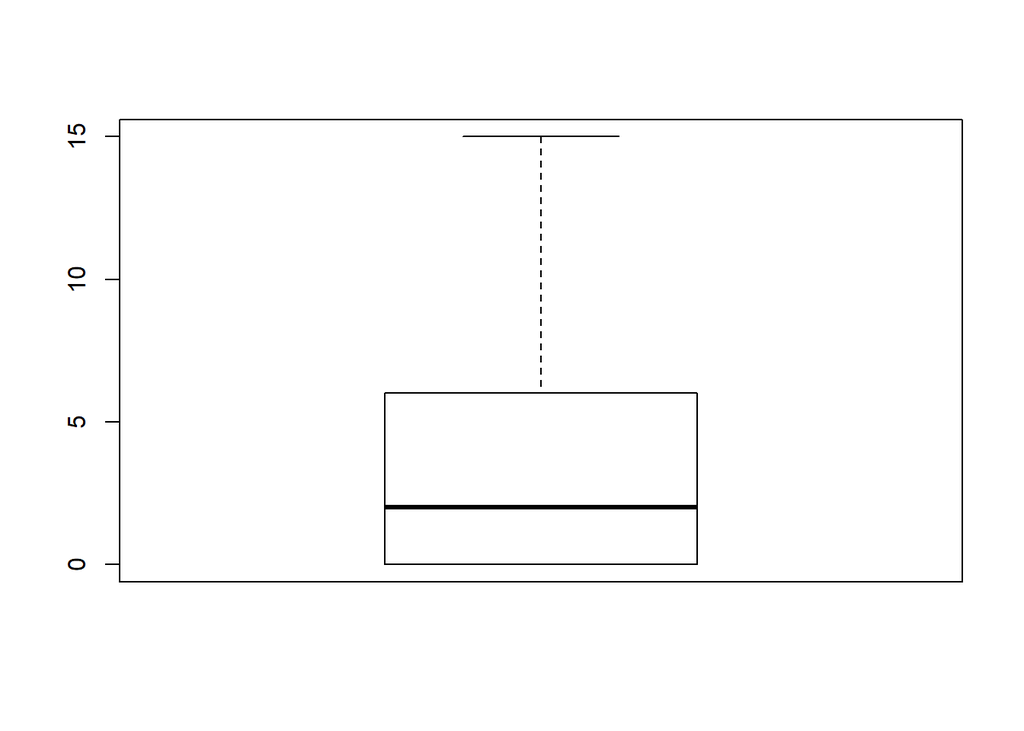

```r
boxplot(data_clean$absences)
```

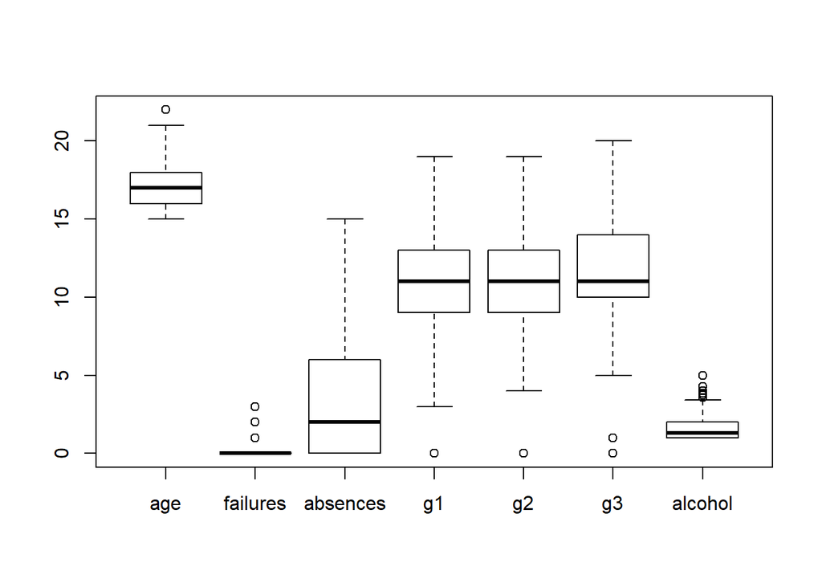

```r
boxplot(data_clean[variables_numericas])
```

#### Resultado final de la limpieza de outliers

Como se pudo observar, los valores atípicos se identifican por medio del boxplot. Se eliminaron outliers en la variable ausencias ya que se identifican valores muy extremos y esto puede afectar el análisis de cluster.

El dataframe final es data_clean

# Entendimiento de datos por medio de visualizaciones

Luego de realizar la limpieza de datos, se procede a la fase de interpretación de los datos.

En esta fase se observará por medio de gráficos la distribución por clases de los estudiantes.

## Análisis descriptivo de las variables categóricas

En esta unidad se conocerá el comportamiento real de cada variable categórica relacionada con cada estudiante que identificará las causas del rendimiento académico.

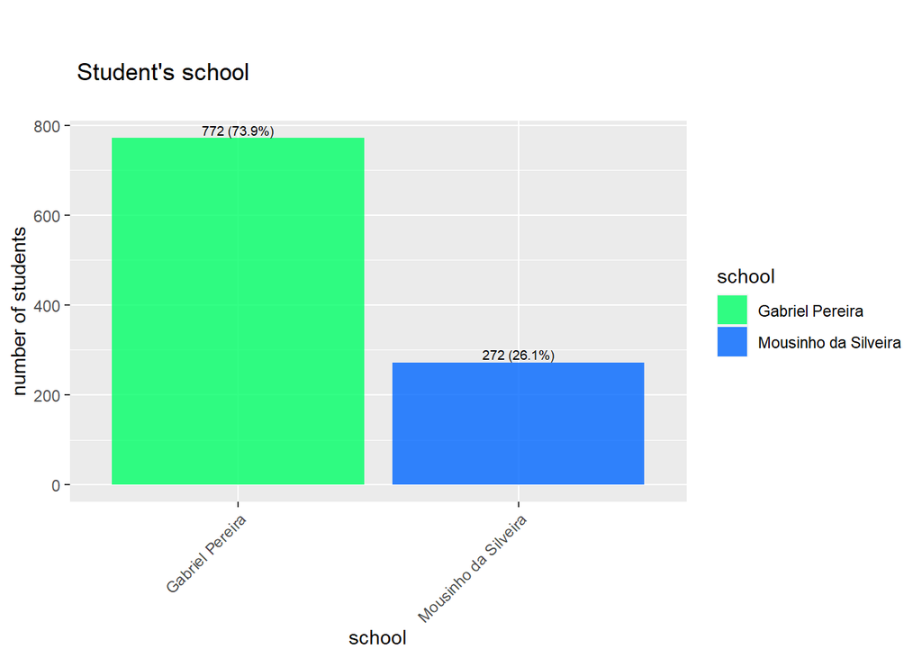

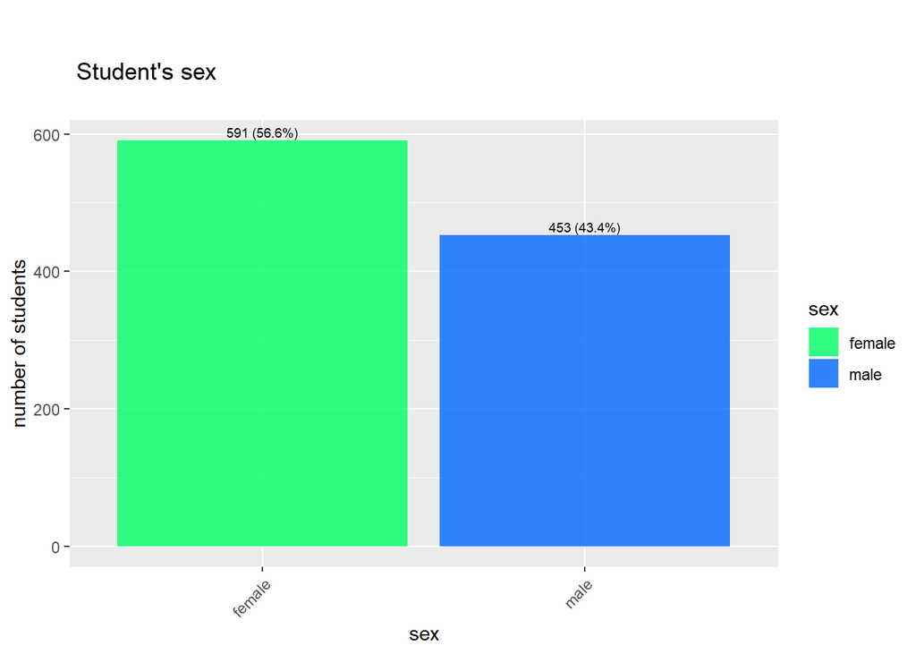

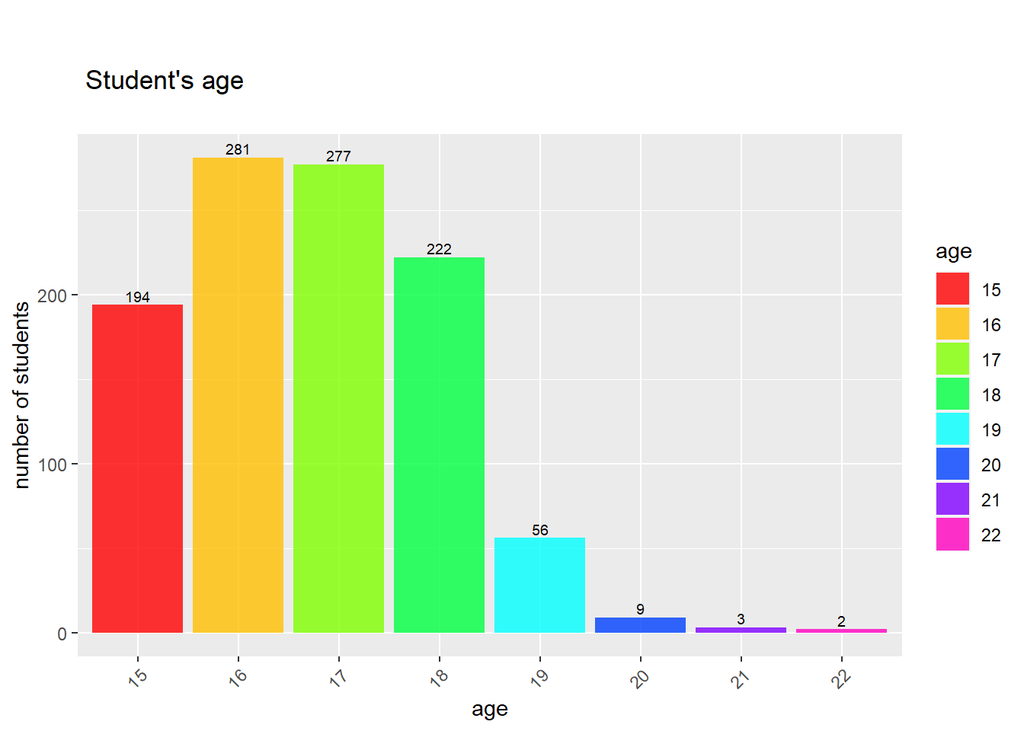

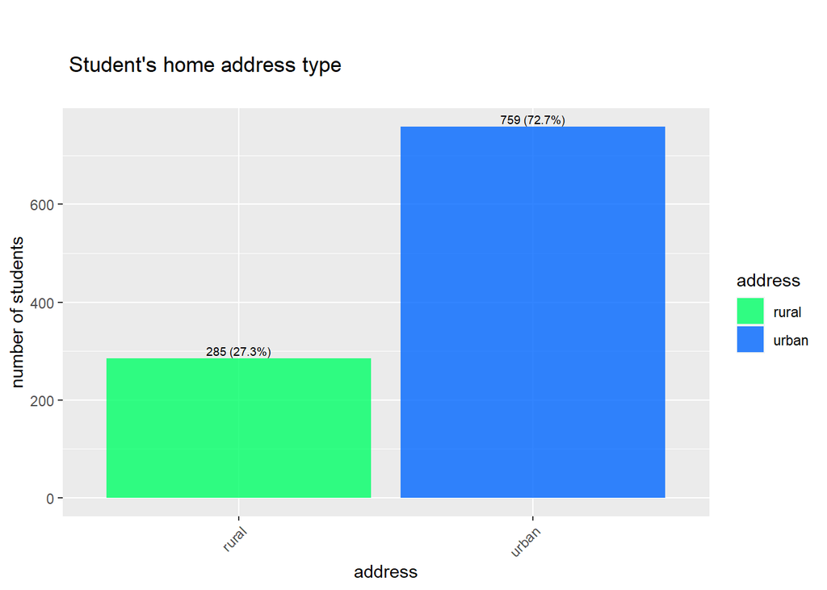

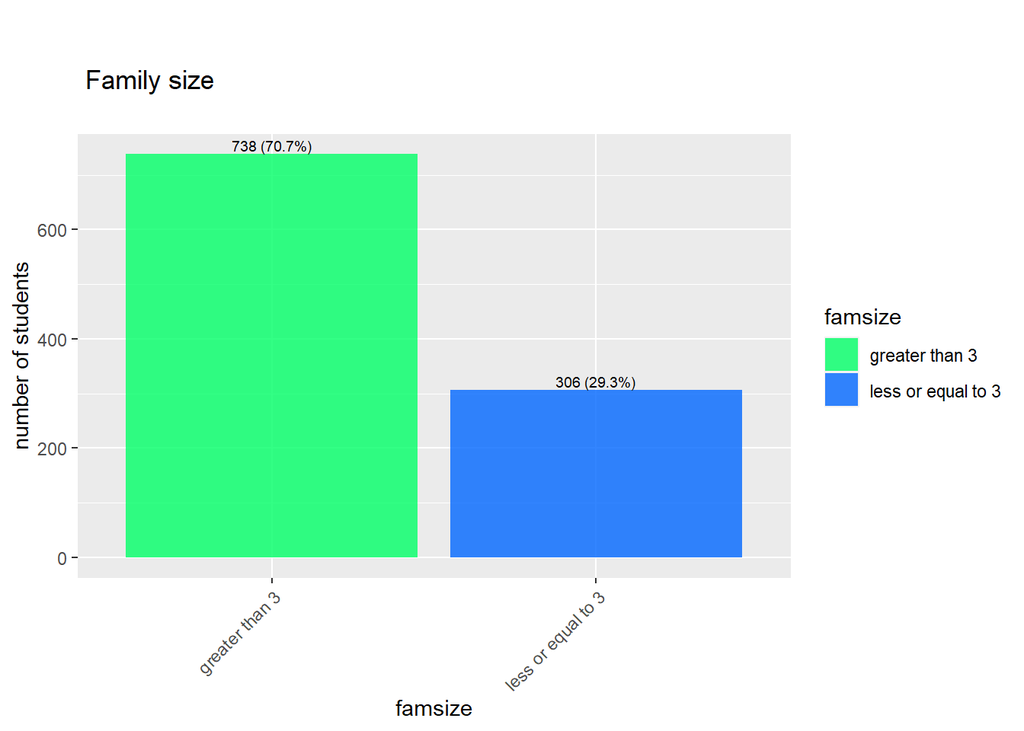

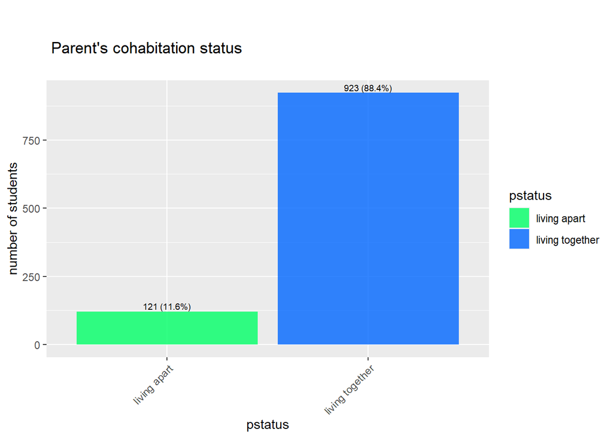

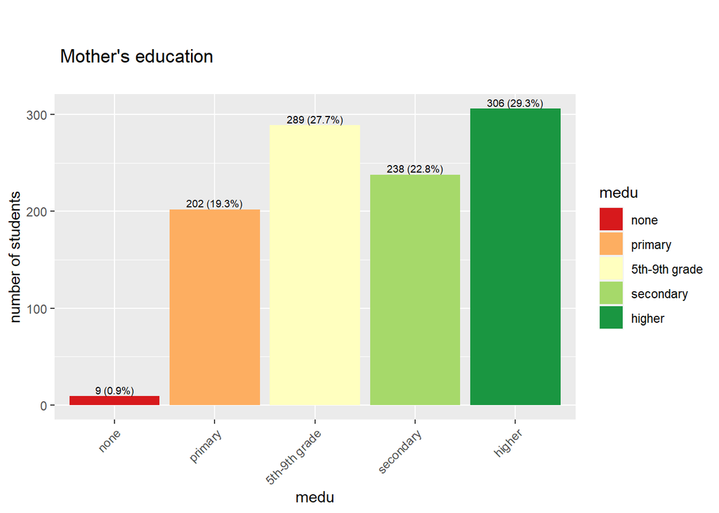

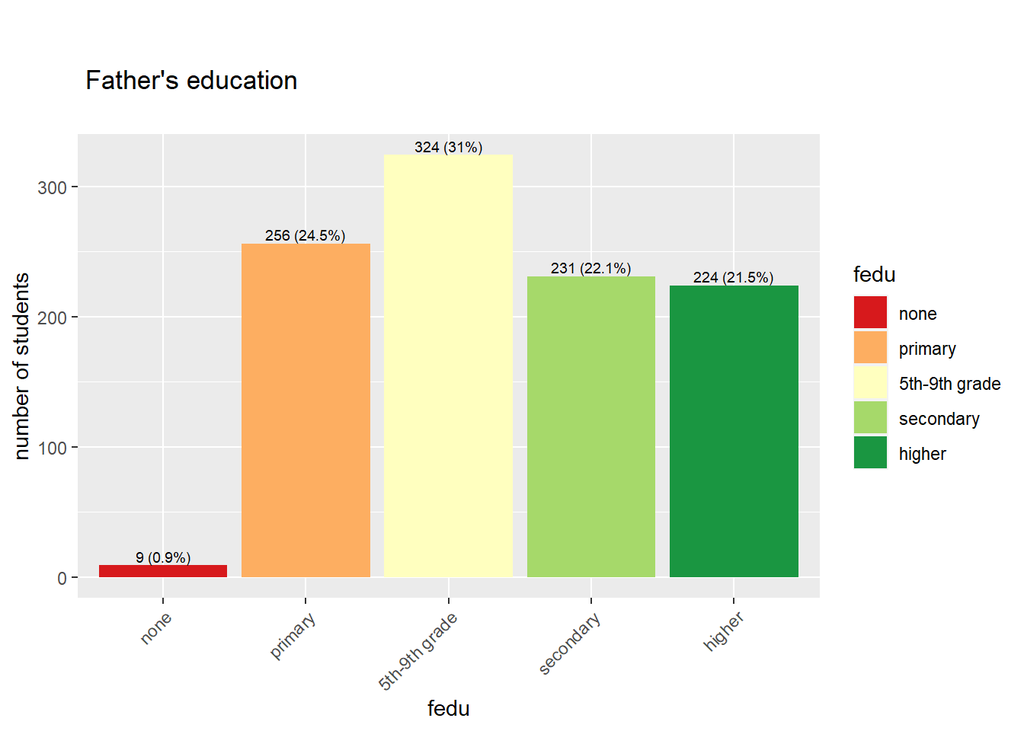

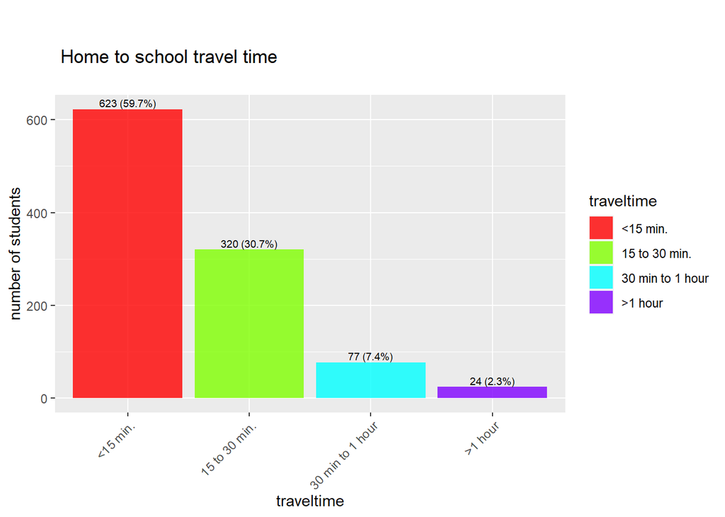

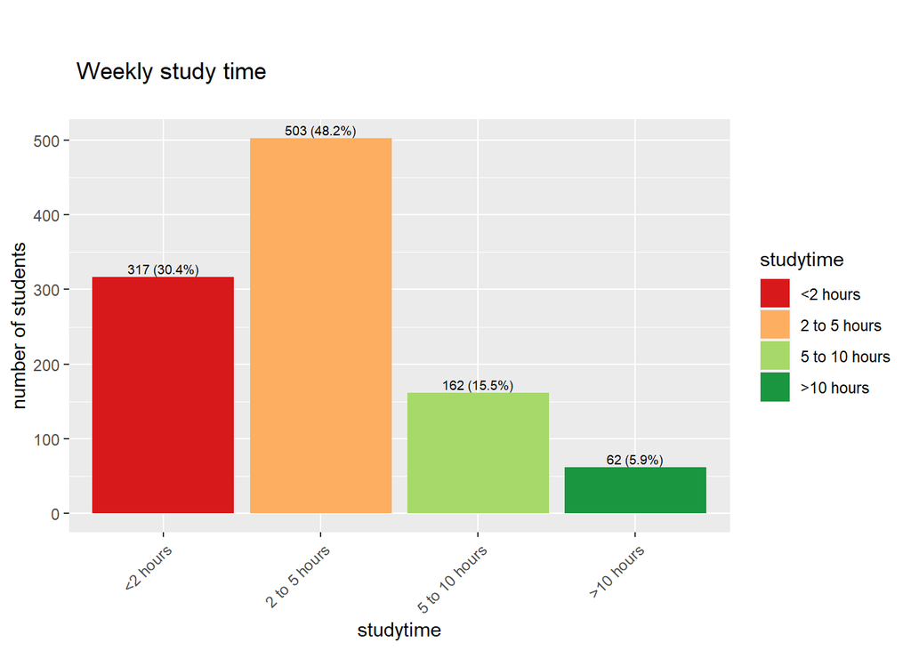

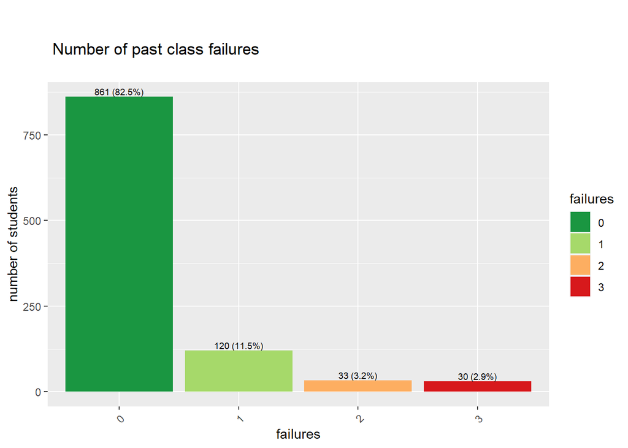

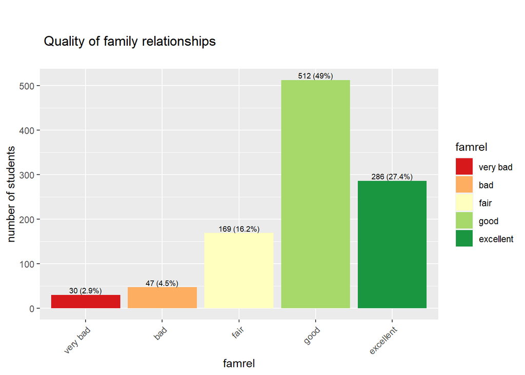

[14 more figures not shown]

```r
factor_var_plot <- function(var, var_name, color){
  df_plot<-as.data.frame(table(data[,var]))
  names(df_plot)<-c(var, "count")

  if( nrow(df_plot)>6 ){ lab<-paste0(df_plot$count)  }
  else{ lab<-paste0(df_plot$count, " (", round(df_plot$count/1044*100,1), "%)")   }

  switch(color,
         rainbow={ cols=rainbow(nrow(df_plot), alpha=0.8) },
         heat={
           cols=heat.colors(nrow(df_plot))
         },
         heat_inverso={
           cols=heat.colors(nrow(df_plot)+2)
           cols=cols[length(cols):3]
           #c[length(c):1]
         },
         doscolores={ cols=c("#00FF66CC","#0066FFCC") #cols=c("plum", "dodgerblue")  #cols=rainbow(nrow(df_plot), alpha=0.8)
         },
         noyes={ cols=c("#FF0000CC","#0000FFCC") },
         semaforo={ cols=brewer.pal(nrow(df_plot),"RdYlGn") },
         semaforo_inverso={
           cols=brewer.pal(nrow(df_plot),"RdYlGn")
           cols=cols[length(cols):1]
           },
         { cols=palette() }
    )



  plot<-ggplot(data=df_plot, aes(x=df_plot[,1], y=df_plot[,2], fill=df_plot[,1]) ) +
    geom_bar(stat="identity")+#scale_fill_brewer(palette="RdYlGn")+

    scale_fill_manual(values=cols)+

    geom_text(aes(label=lab), vjust=-0.3, size=2.5)+
    ggtitle(paste("\n", "\n", var_name,"\n") )  +
    xlab(var) + ylab("number of students") + labs(fill=var)+
    theme(axis.text.x=element_text(angle=45, hjust=1))
  show(plot)

}

for(i in 1:length(variables_discretas)){
  var<-paste(variables_discretas[i])
  var_name<-paste(variables_discretas_names[i])
  color<-variables_discretas_color[i]
  factor_var_plot(var,var_name,color)
}
```

### Interpretación de los resultados

- En las primeras gráficas se observa la distribución por estudiante en cada colegio de portugal, en este caso se evidencia mayor proporción de estudiantes en el colegio Gabriel Pereira, con una participación del 73,9%, mientras que el colegio Mousinho da Silveira tiene una propoción de 26,1%.

- Se identifica que las edades de los alumnos están entre los 15 y 22 años, la mayor concetración esta en las edades 16 y 17 años de edad. se registran pocos alumnos mayores de 18 años de edad.

- La gran población de estudiantes viven en el área urbana con un cubrimiento del 72,7%, mientras que el 27,3% residen en zona rural.

- El 70% de los estudiantes pertenecen a conjuntos familiares con mas de 3 pesonas, mientras que el 30% restante pertenecen a familias con menos de 3 personas.

- El 88% de los estudiantes viven con sus padres, mientras que el 11 % tienen sus padres separados.

- Cuando se habla de educación de las madres de familia de los estudiantes casi el 30% tienen educación universitaria, mientras que 27 % solo han estudiado hasta noveno grado de secundaria. y el 22 % solo han terminado la secundaria, el 19% solo han hecho primaria y 1% no tienen educación escolar.

- En cuanto a los padres de familia, el 31% de ellos solo realizaron estudios hasta noveno grado de secundaria, y el 21% llegaron hasta universidad, el 22% secundaria, el 24% hicieron primaria y el 1% no tienen educación escolar.

- Cuando se les preguntó sobre el tiempo que toman para viajar desde casa al colegio, el 59% contestaron que toman 15 minutos de recorrido, 30% contestaron que se demoran en 15 a 30 minutos, y el resto de la población de estudiantes se demoran mas de media hora para llegar al colegio.

- El 48% de los estudiantes dedican de 2 a 5 horas semanales para estudiar, el 30% estudian menos de 2 horas, el 15% aplican de 5 a 10 horas semanales y un 6% emplean mas de 10 horas de estudio.

- En cuanto a la calidad de la relación familiar el 49% de los estudiantes presenta una “buena” relación con sus familiares.

- El 39% de los estudiantes dicen que su tiempo es medio en cuanto ha tiempo libre, y ese tiempo el 32 % de ellos lo utilizan para estar con sus amigos.

- En cuanto al consumo de alcohol en semana, se evidenció que el 69% de los estudiantes no toman en semana.

- En el fin de semana el 38% de los estudiantes no tienen una actividad alcoholica, solo 7% de ellos son tomadores constantes los dias festivos.

- El 37% de los estudiantes encuestados presentan muy buen estado de salud, solo 13% de ellos presentan inconvenientes en cuanto enfermedades.

- la mayor población de estudiantes al menos han faltado 2 veces al colegio. sin embargo se encuentran registros de 75 ausencias durante el año escolar.

- Se registra que el 78% de los estudiantes aprueban el periodo escolar, mientras que el 22% de ellos no pasan el periodo. se podría interpretar que estos estudiantes presentan en promedio un “buen” rendimiento.

- Solo el 25% aprueban matemáticas, mientras que el 52% aprueban solo portugués, el 12,5% no aprueban matemáticas, y solo un 9 % no aprueba portugués.

- En cuanto al consumo de alcohol, se registra que la mayoría de ellos no tienen un consumo constante de bebidas con alto grado de alcohol.

# Análisis estadístico univariante y bivariante

En esta literal, se requiere realizar un análisis con variables únicas y relacionadas entre sí, verificando correlaciones y covarianzas para dar una mejor interpretación de las variables.

```r
summary(data)
```

```
##                   school        sex           age         address
##  Gabriel Pereira     :772   female:591   Min.   :15.00   rural:285
##  Mousinho da Silveira:272   male  :453   1st Qu.:16.00   urban:759
##                                          Median :17.00
##                                          Mean   :16.73
##                                          3rd Qu.:18.00
##                                          Max.   :22.00
##                famsize               pstatus               medu
##  greater than 3    :738   living apart   :121   none         :  9
##  less or equal to 3:306   living together:923   primary      :202
##                                                 5th-9th grade:289
##                                                 secondary    :238
##                                                 higher       :306
##
##             fedu         mjob               fjob              reason
##  none         :  9   Length:1044        Length:1044        Length:1044
##  primary      :256   Class :character   Class :character   Class :character
##  5th-9th grade:324   Mode  :character   Mode  :character   Mode  :character
##  secondary    :231
##  higher       :224
##
##    guardian                    traveltime          studytime      failures
##  Length:1044        <15 min.        :623   <2 hours     :317   Min.   :0.0000
##  Class :character   15 to 30 min.   :320   2 to 5 hours :503   1st Qu.:0.0000
##  Mode  :character   30 min to 1 hour: 77   5 to 10 hours:162   Median :0.0000
##                     >1 hour         : 24   >10 hours    : 62   Mean   :0.2644
##                                                                3rd Qu.:0.0000
##                                                                Max.   :3.0000
##   schoolsup            famsup              paid            activities
##  Length:1044        Length:1044        Length:1044        Length:1044
##  Class :character   Class :character   Class :character   Class :character
##  Mode  :character   Mode  :character   Mode  :character   Mode  :character
##
##
##
##    nursery             higher            internet           romantic
##  Length:1044        Length:1044        Length:1044        Length:1044
##  Class :character   Class :character   Class :character   Class :character
##  Mode  :character   Mode  :character   Mode  :character   Mode  :character
##
```

[output cut: 15 more lines]

```
##                                  Max.   :75.000   Max.   :19.00
##        g2              g3                file                subject
##  Min.   : 0.00   Min.   : 0.00   math      :395   math           : 25
##  1st Qu.: 9.00   1st Qu.:10.00   portuguese:649   math&portuguese:751
##  Median :11.00   Median :11.00                    portuguese     :268
##  Mean   :11.25   Mean   :11.34
##  3rd Qu.:13.00   3rd Qu.:14.00
##  Max.   :19.00   Max.   :20.00
##  student_key         bing3                       result       alcohol
##  Length:1044        fail:230   aprueba math         :265   Min.   :1.000
##  Class :character   pass:814   aprueba portuguese   :549   1st Qu.:1.000
##  Mode  :character              no aprueba math      :130   Median :1.290
##                                no aprueba portuguese:100   Mean   :1.721
##                                                            3rd Qu.:2.178
##                                                            Max.   :5.000
```

**Resumen de las variables numéricas**

```r
data_num<-data[variables_numericas]
summary(data_num)
```

```
##       age           failures         absences            g1
##  Min.   :15.00   Min.   :0.0000   Min.   : 0.000   Min.   : 0.00
##  1st Qu.:16.00   1st Qu.:0.0000   1st Qu.: 0.000   1st Qu.: 9.00
##  Median :17.00   Median :0.0000   Median : 2.000   Median :11.00
##  Mean   :16.73   Mean   :0.2644   Mean   : 4.435   Mean   :11.21
##  3rd Qu.:18.00   3rd Qu.:0.0000   3rd Qu.: 6.000   3rd Qu.:13.00
##  Max.   :22.00   Max.   :3.0000   Max.   :75.000   Max.   :19.00
##        g2              g3           alcohol
##  Min.   : 0.00   Min.   : 0.00   Min.   :1.000
##  1st Qu.: 9.00   1st Qu.:10.00   1st Qu.:1.000
##  Median :11.00   Median :11.00   Median :1.290
##  Mean   :11.25   Mean   :11.34   Mean   :1.721
##  3rd Qu.:13.00   3rd Qu.:14.00   3rd Qu.:2.178
##  Max.   :19.00   Max.   :20.00   Max.   :5.000
```

**Desviación de cada variable numérica**

```r
sapply(data_num,sd)
```

```
##       age  failures  absences        g1        g2        g3   alcohol
## 1.2399747 0.6561418 6.2100166 2.9833939 3.2850711 3.8647958 0.9269683
```

Se evidencia mayor disperción en la variable ausencias, “absences”.

**Matriz de correlación**

```r
correlacion<-cor(data_num)
correlacion
```

```
##                 age    failures    absences          g1          g2          g3
## age       1.0000000  0.28236357  0.15319565 -0.12412125 -0.11947474 -0.12528243
## failures  0.2823636  1.00000000  0.09999785 -0.37417487 -0.37717218 -0.38314528
## absences  0.1531956  0.09999785  1.00000000 -0.09242463 -0.08933169 -0.04567058
## g1       -0.1241212 -0.37417487 -0.09242463  1.00000000  0.85873875  0.80914172
## g2       -0.1194747 -0.37717218 -0.08933169  0.85873875  1.00000000  0.91074316
## g3       -0.1252824 -0.38314528 -0.04567058  0.80914172  0.91074316  1.00000000
## alcohol   0.1327481  0.12410073  0.14877659 -0.16222869 -0.14306963 -0.13677155
##             alcohol
## age       0.1327481
## failures  0.1241007
## absences  0.1487766
## g1       -0.1622287
## g2       -0.1430696
## g3       -0.1367715
## alcohol   1.0000000
```

**Gráfica de correlaciones**

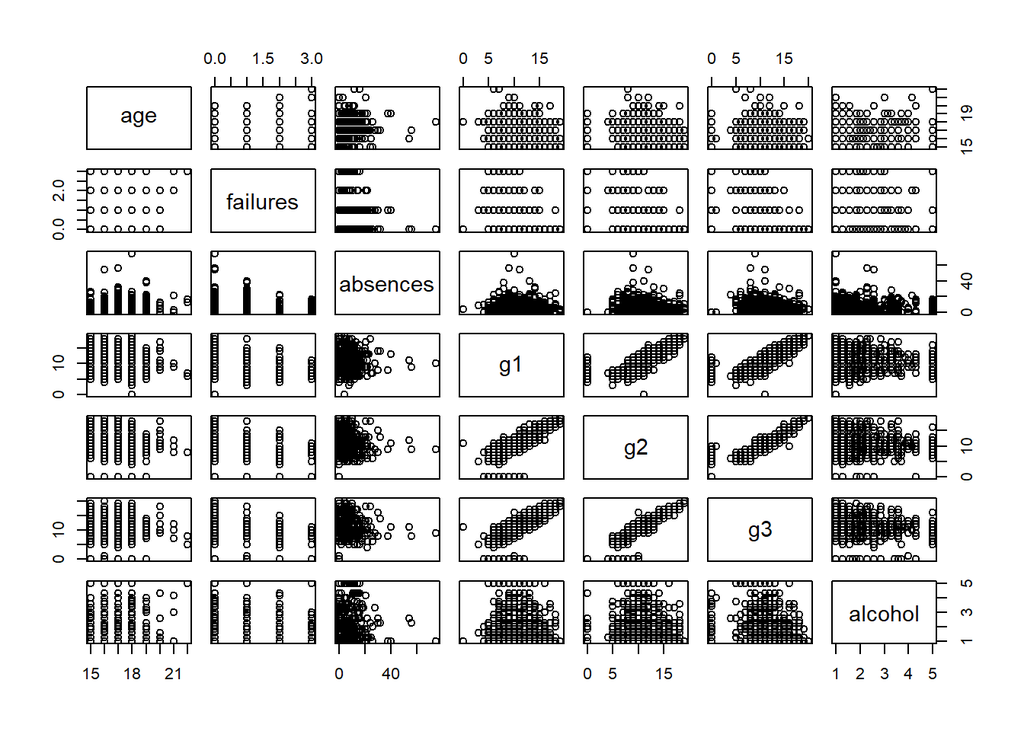

```r
plot(data_num)
```

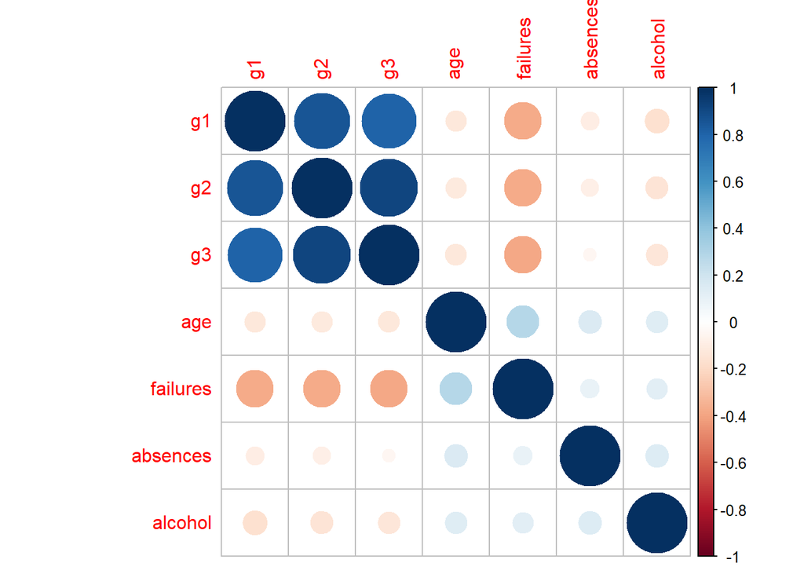

```r
corrplot(correlacion, order = "hclust")
```

#### Análisis entre la edad y ausencias

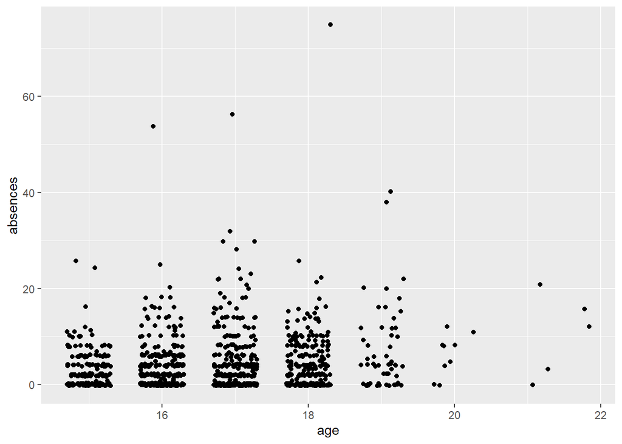

```r
plot1<-ggplot(data,aes(x=age,y=absences))+ geom_point(position = position_jitter(w=0.3,h=0.3))

plot1
```

```r
round(tapply ( data$absences,data$age,mean ),1)
```

```
##   15   16   17   18   19   20   21   22
##  3.1  3.9  4.9  4.9  6.9  6.2  8.0 14.0
```

**Análisis entre edad + g3** **age + g3**

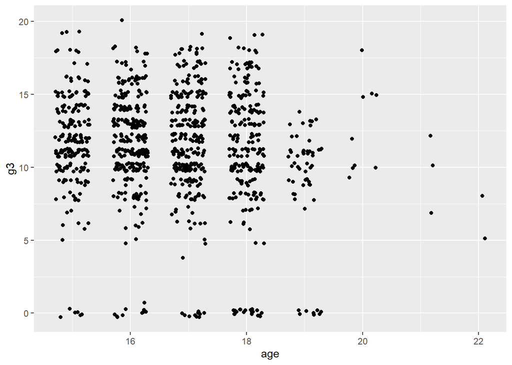

```r
plot2 <- ggplot (data,aes (x=age,y=g3)) +
geom_point ( position=position_jitter ( w=0.3,h=0.3) )
plot2
```

```r
round(tapply ( data$g3,data$age,mean ),1)
```

```
##   15   16   17   18   19   20   21   22
## 11.7 11.6 11.6 11.0  9.0 12.7  9.7  6.5
```